# Combining partial covariance matrices using CovCombR package

Deniz Akdemir and Julio Isidro Sanchez

2019-12-17

### Illustration: Combining data from independent phenotypic experimets.

Lets load the package and datasets.

```r
library(CovCombR)
data("BarleyPheno")
```

The datasets are very heterogenous, each trial only involves a few traits. We can see this from the following image. Mean number of traits per trait is about 6.

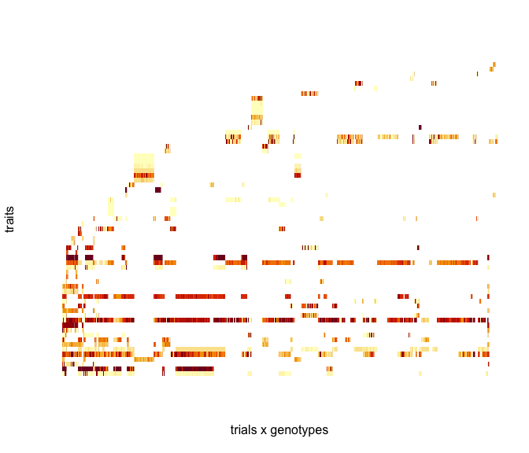

```r
library(plyr)
dataall<-rbind.fill(BarleyPheno)
image(as.matrix(dataall[,-c(1,2)]), xlab="trials x genotypes", ylab="traits", axes=FALSE)
```

```r
covlist<-lapply(BarleyPheno, function(x){cov(x,use="pairwise.complete.obs")})
covlist<-lapply(covlist,function(x){cov2cor(as.matrix(Matrix::nearPD(x)$mat))})
mean(c(unlist(lapply(covlist,function(x){nrow(x)}))))
```

```
## [1] 6.113402
```

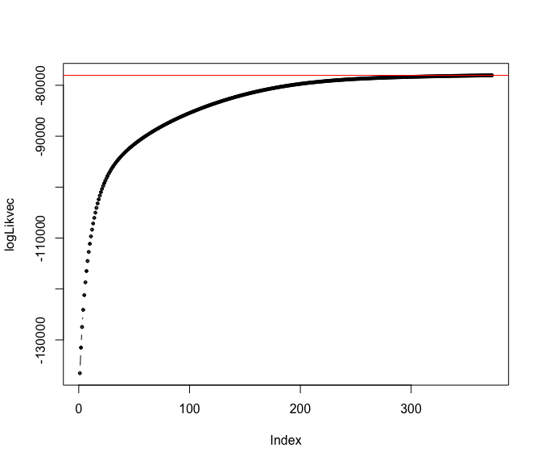

```r
BigK<-CovComb(Klist=covlist, maxiter=1000,  loglik = TRUE, plotll = TRUE)
```

Combined covariance matrix has 67 traits. Some of the relationships in this estimated relationship matrix have never been observed but wer infered by the Wishart EM algorithm.

```r
dim(BigK[[1]])
```

```
## [1] 67 67
```

We can visualise the estimated phenomic covariance matrix.

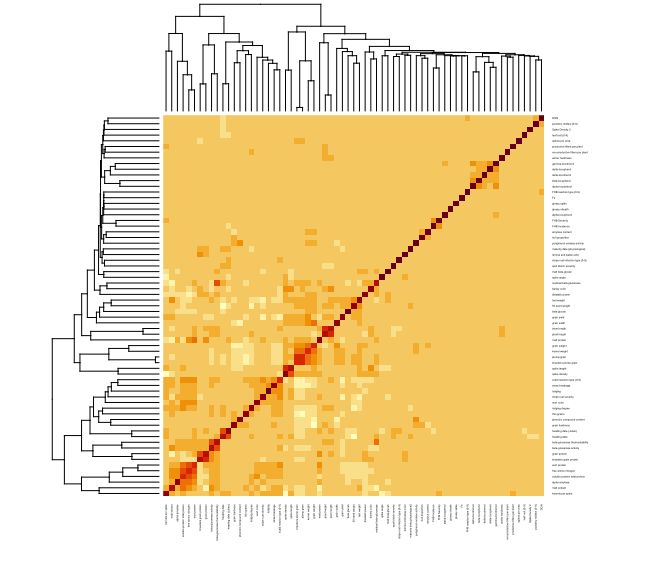

```r
heatmap(as.matrix(BigK[[1]]), cexRow = .2,cexCol = .2)
```

### Adding sparsity to the estimated covariance

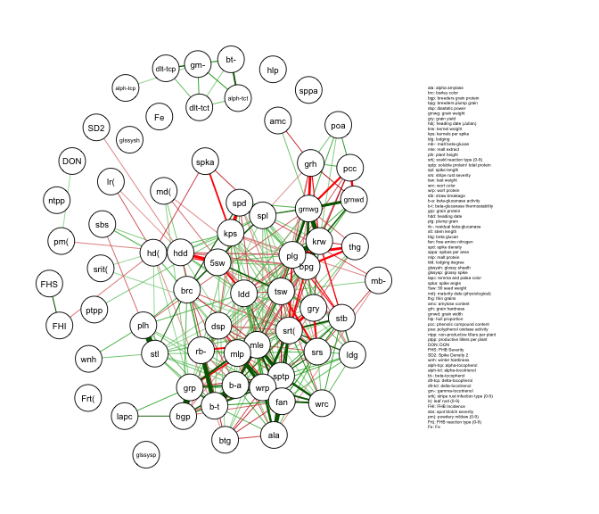

```r
Graph_lasso <- qgraph::qgraph(BigK[[1]], graph = "cor", directed=FALSE,details = FALSE,esize = 10,sampleSize=3000, layout="spring",nodeNames = rownames(BigK[[1]]),threshold = "hochberg", legend.cex=.15)
```

## The Wishart EM-Algorithm

In this section, we briefly describe the estimation algorithm.

Let $A=\left\{a_1, a_2, \ldots, a_m \right\}$ be the set of not necessarily disjoint subsets of genotypes covering a set of $K$ (i.e., $K= \cup_{i=1}^m a_i$) with total $n$ genotypes. Let $G_{a_1}, G_{a_2},\ldots, G_{a_m}$ be the corresponding sample of covariance matrices.

Starting from an initial estimate $\Sigma^{(0)}=\nu\Psi^{(0)},$ the Wishart EM-Algorithm repeats updating the estimate of the covariance matrix until convergence:
$$\begin{equation}\label{eq:covar1} \begin{split} \Psi^{(t+1)} & =\frac{1}{\nu m}\sum_{a\in A}P_a\left[ \begin{matrix}
G_{aa} & G_{aa}(B^{(t)}_{b|a})' \\
B^{(t)}_{b|a}G_{aa} & \nu \Psi^{(t)}_{bb|a}+ B^{(t)}_{b|a}G_{aa}(B^{(t)}_{b|a})'
\end{matrix}\right]P'_a
\end{split}
\end{equation}$$
where $B^{(t)}_{b|a}=\Psi^{(t)}_{ab}(\Psi^{(t)}_{aa})^{-1},$ $\Psi^{(t)}_{bb|a}=\Psi^{(t)}_{bb}-\Psi^{(t)}_{ab}(\Psi^{(t)}_{aa})^{-1}\Psi^{(t)}_{ba},$ $a$ is the set of genotypes in the given partial covariance matrix and $b$ is the set difference of $K$ and $a.$ The matrices $P_a$ are permutation matrices that put each matrix in the sum in the same order. The initial value, $\Sigma^{(0)}$ is usually assumed to be an identity matrix of dimesion $n.$ The estimate $\Psi^{(T)}$ at the last iteration converts to the estimated covariance with $\Sigma^{(T)}=\nu\Psi^{(T)}.$

A weighted version of this algorithm can be obtained replacing $G_{aa}$ in Equation~ with $G^{(w_a)}_{aa}=w_aG_{aa}+(1-w_a)\nu\Psi^{(T)}$ for a vector of weights $(w_1,w_2,\ldots, w_m)'.$

## References

Adventures in Multi-Omics I: Combining heterogeneous data sets via relationships matrices Deniz Akdemir, Julio Isidro Sanchez, November 2019; arXiv:1912.03358.

qgraph: Network Visualizations of Relationships in Psychometric Data. Sacha Epskamp, Angelique O. J. Cramer, Lourens J. Waldorp, Verena D. Schmittmann, Denny Borsboom (2012). Journal of Statistical Software, 48(4), 1-18. http://www.jstatsoft.org/v48/i04/.